# EXPLORATORY ANALYSIS OF PROSPER LOAN DATA

by Bingson Huang

## Abstract

This report looks at the evolution of the Prosper Marketplace lending platform through exploratory data analysis of historic loan data. My broader objective is to create new visualization templates that can be modified and recycled in future research.

# TABLE OF CONTENTS

1. INTRODUCTION
   - Overview of the data set
2. BACKGROUND
   - Geographic Loan Distribution  
     Figure 1: Dollars Lent in 2013 by State  
     Figure 2: Dollars Lent in 2013 as a Percentage of State GDP
   - Growth Trends  
     Figure 3: Loan Growth Over Time
   - Government Intervention  
     Figure 4: Benchmark Interest Rates
   - Loan Defaults and Durations  
     Figure 5: Cumulative Percentage of Lost Principal by Loan Vintage  
     Figure 6: Loan Origination Term at Issuance
   - Tricks with the Truth  
     Figure 7: Prosper Annual Report Comparison
3. BLACK BOX MYSTERIES
   - Anatomy of a Prosper rating  
     Figure 8: Credit Score Distributions  
     Figure 9: Credit Score Correlation Matrix
   - Default Prediction Accuracy  
     Figure 10: Historic Default Probability with Regression Lines
   - Prosper Ratings Expected Returns and Borrowing Rates Through Time  
     Figure 11: Estimated Return by Prosper Rating  
     Figure 12: Dollar-weighted Average Estimated Return by Prosper Rating  
     Figure 13: Borrower Rate by Prosper Rating  
     Figure 14: Borrower Rate by Prosper Rating Split by Marketplace Regime
4. FINAL PLOTS & SUMMARY
   - Plots  
     Figure 15: Cumulative Percentage of Lost Principal by Marketplace Regime  
     Figure 16: Placement of riskiest FICO score buckets  
     Figure 17: Credit Rating Distributions 2013  
     Figure 18: FICO vs Prosper Rating Distribution Through Time
   - Reflection
5. REFERENCES

# INTRODUCTION

My exploration of the data set begins by looking at broad measures of lending activity to get a feel for the asset class as well as Prosper’s business model. As I come across unexpected or unusual relationships in the data, I experiment with more extensive transformations and multivariate visualizations to expand on earlier ideas and uncover new insights.

## Overview of the data set

The Prosper loan data set contains 113061 unique loan records (rows) and 81 variables (columns) covering the period spanning 2005-11-15 to 2014-03-12. Benchmark interest rate and state level GDP data was also combined with loan data to look at relationships in the context of the broader economy.

While looking for a unique key to join together different subsets I noticed some duplicate ListingNumbers. If we removed the ProsperScore variable (column 16), the data set would contain 871 duplicate observations. For example, there are 6 records for ListingNumber 951186 with values identical in all columns except for Prosper score. To deal with these duplicate entries I created two subsets of the original data set: (1) one with no Prosper score column and duplicate entries removed, and (2) one with a Prosper score column and all ambiguous entires removed (first instance included). The latter was used for credit score related analysis, while the former was used for everything else. Omitted data in the second set represented around 1% of total lent dollar value and about 0.7% of unique records.

Return to table of contents

# BACKGROUND

## Geographic Loan Distribution

To get a feel for the geographic distribution of borrowers, let’s look at dollar-weighted debt issuance by borrower state for the most recent full year in the dataset.

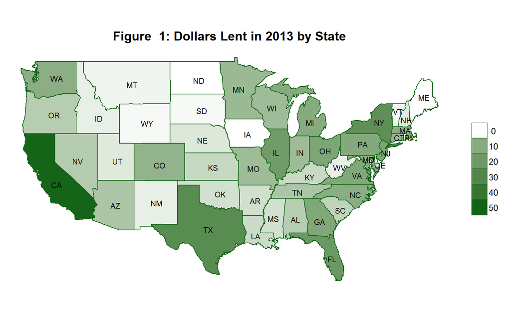

#### Table 1: Top 5 states by dollar issuance

```
## Source: local data frame [5 x 4]
##
##        state LoanAmount loans avg.loan.size
##        (chr)      (dbl) (int)         (dbl)
## 1 california   49323273  4469         11037
## 2      texas   27415163  2446         11208
## 3   new york   25521482  2431         10498
## 4    florida   20335291  2028         10027
## 5   illinois   18200050  1669         10905
```

As expected, the largest state economies were associated with the most Prosper lending activity. Of note, the biggest P2P lenders (Lending Club, Prosper and SoFi) are all based in San Francisco, explaining some of the borrower concentration in California.

To adjust for differences in regional economic activity, I divided 2013 Prosper issuance by 2013 state [GDP](https://www.bea.gov/) in the next figure.

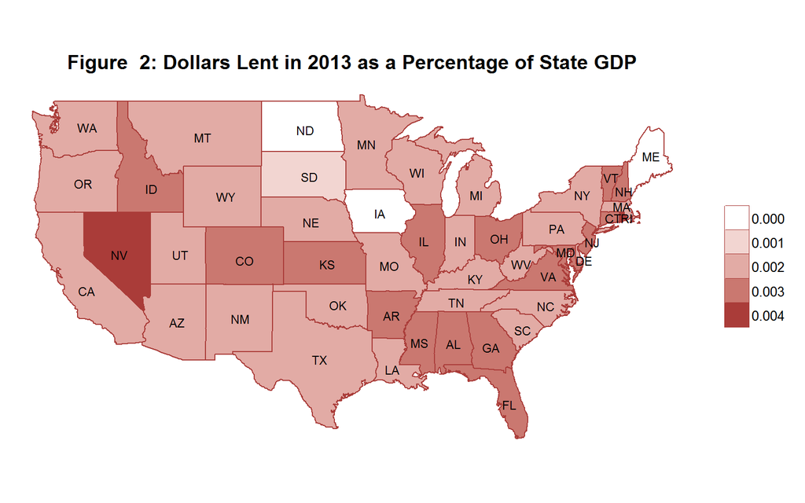

Figure 2 offers a more easy to understand borrower distribution: white regions—Iowa, Maine, and North Dakota—are states that still forbid P2P lending, while the darker ones tended to match states with a high percentage of underwater mortgages. For instance, the top 5 states with properties seriously underwater according to RealtyTrac in the first quarter of 2014 were:

1. Nevada (34%)
2. Florida (31%)
3. Illinois (30%)
4. Michigan (29%)
5. Ohio (27%)

##### Source: [RealtyTrac](http://www.housingwire.com/articles/29707-the-states-and-cities-with-the-most-underwater-homes)—to be seriously underwater, the combined loan amount secured by the property is at least 25% higher than the property’s market value.

#### Table 2: Summary of 2013 state data

```
##    LoanAmount           loans        avg.loan.size        gdp                 dgdp
##  Min.   :  590200   Min.   :  60.0   Min.   : 8942   Min.   :2.700e+10   Min.   :0.001343
##  1st Qu.: 1924785   1st Qu.: 180.8   1st Qu.: 9895   1st Qu.:9.238e+10   1st Qu.:0.002007
##  Median : 4792085   Median : 471.0   Median :10209   Median :2.043e+11   Median :0.002377
##  Mean   : 7446621   Mean   : 706.5   Mean   :10380   Mean   :3.162e+11   Mean   :0.002376
##  3rd Qu.: 8919624   3rd Qu.: 849.5   3rd Qu.:10805   3rd Qu.:4.111e+11   3rd Qu.:0.002715
##  Max.   :49323273   Max.   :4469.0   Max.   :12621   Max.   :2.055e+12   Max.   :0.004059
```

##### dgdp = 2013 new P2P debt issuance / State GDP

To help put the above numbers in perspective, debt issued through Prosper in 2013 was around 357 million. The two largest P2P lenders combined, Lending Club and Prosper (~98% of the market), issued $2.4 billion in new loans, representing about $3% of the 74.2 billion in new 2013 consumer debt issued by US banks, Finance companies, and credit unions combined (Source: [Federal Reserve](http://www.federalreserve.gov/releases/g19/current/#table3)). These figures not only illustrate the infancy of the P2P lending market but also its tremendous potential.

In light of the darker regions in Figure 2 and the fact that 79% of 2013 Prosper loan dollars went towards rolling over preexisting debt, I should take a closer look at how the company manages credit risk. But first, let’s take a look at Prosper’s loan portfolio over time to lay the foundation for later analysis.

## Growth Trends

Because the dataset doesn’t have a full year of 2014 data, it’s easier to interpret recent trends using quarterly figures on the right (Figure 3).

#### Figure 3: Loan Growth Over Time

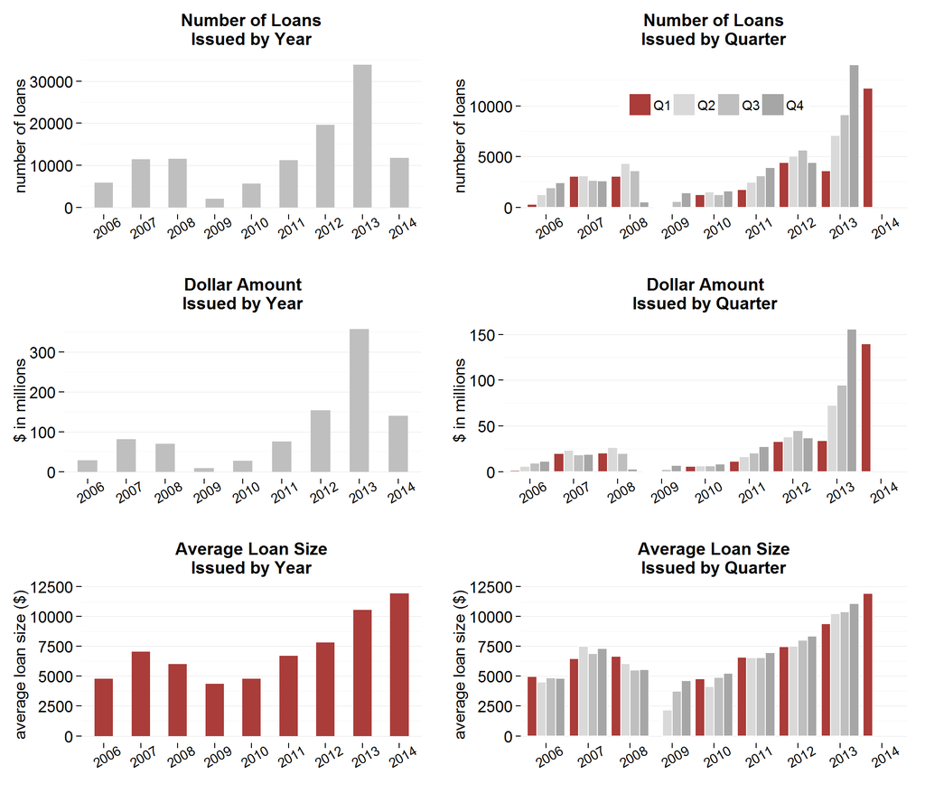

#### Table 3: Annual Growth

```
## Source: local data frame [9 x 5]
##
##    year   dollars count  avg.loan dollar.gwth.pct
##   (chr)     (dbl) (int)     (dbl)           (dbl)
## 1  2006  28124699  5902  4765.283              NA
## 2  2007  80787786 11460  7049.545           187.2
## 3  2008  69560850 11551  6022.063           -13.9
## 4  2009   8914396  2047  4354.859           -87.2
## 5  2010  26940486  5652  4766.540           202.2
## 6  2011  75138013 11228  6692.021           178.9
## 7  2012 153175116 19553  7833.842           103.9
## 8  2013 357437822 33912 10540.158           133.4
## 9  2014 139950560 11734 11926.927              NA
```

##### Note: 2014 only has one quarter of data

#### Table 4: Quarter-on-Quarter Growth

```
## Source: local data frame [8 x 6]
##
##    year quarter   dollars count  avg.loan dollar.gwth.pct
##   (chr)  (fctr)     (dbl) (dbl)     (dbl)           (dbl)
## 1  2006      Q1   1557387   314  4959.831              NA
## 2  2007      Q1  19929121  3079  6472.595          1179.7
## 3  2008      Q1  20469566  3074  6658.935             2.7
## 4  2010      Q1   5933690  1243  4773.685              NA
## 5  2011      Q1  11471873  1744  6577.909            93.3
## 6  2012      Q1  33064180  4435  7455.283           188.2
## 7  2013      Q1  33942509  3616  9386.756             2.7
## 8  2014      Q1 139950560 11734 11926.927           312.3
```

##### Note: 2014Q1 is missing half a month of March data.

One factor often overlooked when looking at rising P2P transaction volumes is the cost to generate growth. Prosper only had its first profitable quarter ever in 2014Q3. For most P2P lenders, marketing/R&D costs have been rising faster than revenues in the pursuit of *network effects*. Or to put it another way, Prosper management believes that as its participant pool grows, the company gains brand awareness, more potential borrowers to source inventory from (improving risk-adjusted lender returns), and more data to improve risk models, creating a self-reinforcing growth cycle.

However, the added challenge to the industry is that many borrowers turn to peer-to-peer lenders only after their banks have rejected them. As a result, online lenders have to develop better credit scoring algorithms to mitigate adverse selection risk (expanded on further below). Under pressure to meet wall street growth expectations, there’s a temptation among P2P lenders to relax rules and pitch loans to those at the riskier end of the credit spectrum. Because of the black box nature of these algorithms, it’s hard to evaluate the true risk borne by investors. Many institutional money managers will wait to see how P2P loans perform over the next downturn, before deploying serious capital into the asset class.

Returning to the panels in Figure 3, the most prominent features are the dip loan issuance in the second half of 2008 and another at the start of 2013. I will pay particular attention to these periods as I incorporate more variables into my analysis.

## Government Intervention

Explaining the first regime shift in Figure 3 at the end of 2008, the SEC forced Prosper (and other P2P lenders) to change how they priced loans. This period also coincided with the announcement of the Fed’s zero interest rate policy and the start of a massive quantitative easing program to reflate the economy—print enough money to get the nominal GDP growth rate marginally above the nominal interest rate, alleviating pressure on borrowers. For more on the relationship between central bank intervention, interest rates, and debt cycles please visit [www.economicprinciples.org](http://www.economicprinciples.org/)

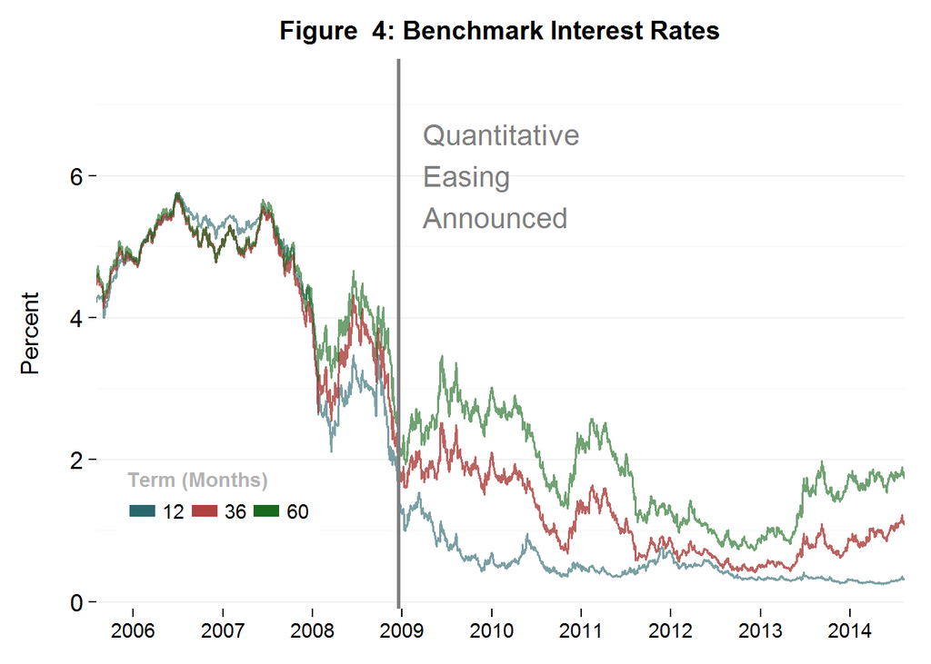

##### Source: [Federal Reserve](http://www.federalreserve.gov/releases/h15/update/)

To better understand Prosper’s 2009 restructuring, it helps to understand how the P2P lending industry was first conceived. Early Peer-to-peer lending was born out of a desire to create a personal connection between borrower and lender, and therefore make borrowers more likely to repay their debts compared to people with similar obligations to a faceless bank.

###### Prosper 1.0 (2006 – 2008)

From 2006 to 2008 Prosper operated as an eBay-style marketplace under the above assumption, where variable-rate loans were ultimately priced by borrowers and investors themselves in a [dutch auction-style](https://cs.stanford.edu/people/jure/pubs/prosper-www11.pdf) system. However, lax borrower screening resulted in an adverse selection problem that manifested in high loan default rates during the crisis—i.e. Prosper borrowers with a given FICO score were [more likely to default](http://blogs.reuters.com/felix-salmon/2010/01/19/the-problem-with-peer-to-peer-lending/) on their debts than most others with the same credit score.

###### Prosper 2.0 (2009 – present)

Heavy P2P investor losses at the height of the credit crisis attracted the attention of the SEC, forcing Prosper to temporarily suspend loan issuance in 2009 while it restructured its business to take a more active role in managing borrower credit risk. Since emerging from its 2009 quiet period, Prosper has taken over the approval of borrowers and the pricing of loans using a proprietary credit scoring model.

## Loan Defaults and Durations

Figure 5 highlights the dramatic drop-off in defaults following central bank intervention and the transition to Prosper’s new risk management framework in 2009. As loan volumes rise (Figure 3), we see that the rate of cumulative defaults in 2011-2012 vintages rises faster than those of older vintages at comparable points in each cohort’s loan maturity schedule. This is reflected in the fact that with 35% and 62% of 2011 and 2012 loan principal outstanding, default rates for these vintages are already above those of mostly retired 2009-2010 vintages—and that’s before accounting for the moderating effects of longer average issuance maturity in later vintages (Figure 6).

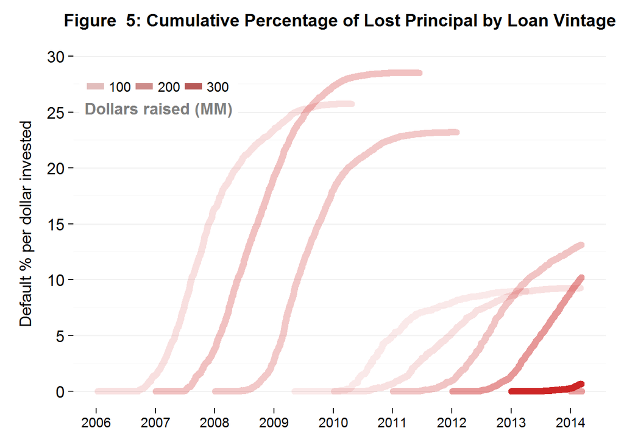

#### Table 5: Cumulative Percentage of Lost Principal by Vintage

```
## Source: local data frame [9 x 5]
## Groups: OrigYear [9]
##
##   OrigYear dollars.raised dollars.outstanding pct.matured pct.charged.off
##      (chr)          (dbl)               (dbl)       (dbl)           (dbl)
## 1     2006       28124699                   0       100.0            25.7
## 2     2007       80787786                   0       100.0            28.5
## 3     2008       69560850                   0       100.0            23.2
## 4     2009        8914396                   0       100.0             9.0
## 5     2010       26940486              310300        98.8             9.2
## 6     2011       75138013            26334824        65.0            13.1
## 7     2012      153175116            95270074        37.8            10.2
## 8     2013      357437822           334033643         6.5             0.7
## 9     2014      139950560           139345974         0.4             0.0
```

However, in an encouraging sign for 2013 loans, with 6.5% of loan dollars closed (paid back or charged-off as a loss), 2011 and 2012 had cumulative default rates of 1% and 1.1%, versus 0.7% for 2013.

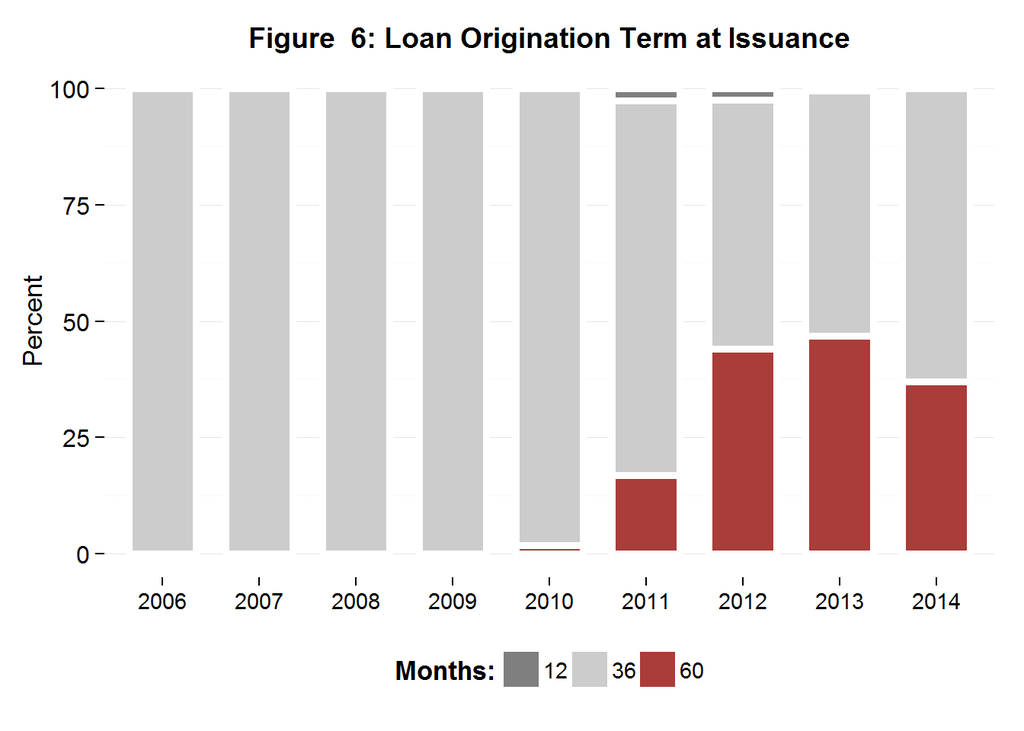

From a maturity perspective, we see how lower 2009-2010 vintage default rates and the new low yield environment (Figure 4 ) has attracted investors willing to park their money in Prosper loans for longer periods of time. If Prosper does a good job at managing credit risk through the next downturn, they should benefit from a surge of capital from a larger pool of institutional investors with long-term liabilities (e.g. insurance companies and pension funds), increasing average loan durations.

## Tricks with the Truth

For a comparison with Figure 5, below are charts from the company’s last two annual reports ([2013 annual report—Pg. 13](https://www.sec.gov/Archives/edgar/data/1416265/000114036114014832/form10k.htm), [2014 annual report—Pg. 20](https://www.sec.gov/Archives/edgar/data/1416265/000156459015002385/prosper-10k_20141231.htm#Item_1)).

#### Figure 7: Prosper Annual Report Comparison

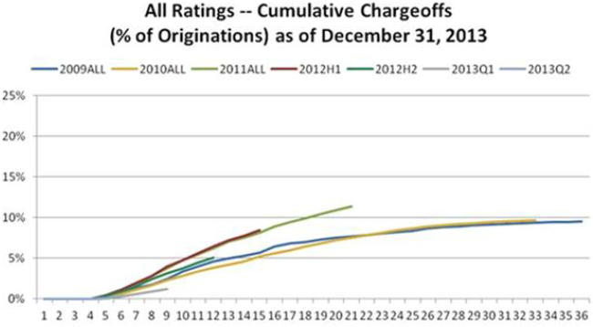

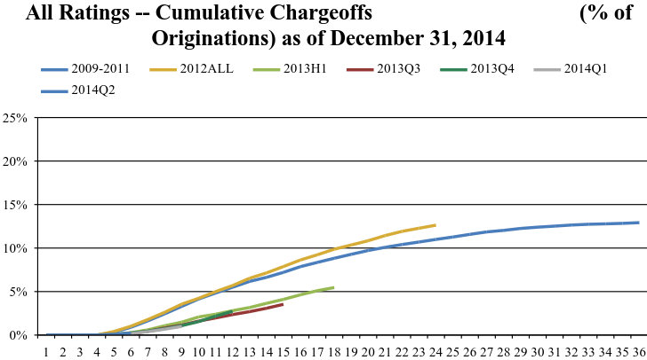

Notice how Prosper changes its presentation between years, using a 3-year average to offset higher default rates in 2011 with lower ones in 2009-2010, obscuring the fact that defaults in the former are 40% higher than those of the latter, and still rising!

Worse yet, because the company is using a loan-weighted calculation instead of a dollar-weighted calculation, loans of different dollar amounts are being treated the same, distorting figures in the company’s favor (Figure 3: 2011 average loan size was 1.5 times larger than those of 2009-2010 vintages).

Return to table of contents

# BLACK BOX MYSTERIES

Modern finance revolves around the law of one price: *equally risky future cashflows should be equally priced today (no-arbitrage pricing)*. For instance, if both a U.S. Government Treasury note and a high risk Prosper loan seemed likely to return 7% per year, everyone would rush to buy the former (driving up its price and reducing its prospective return) and dump the latter (driving down its price and increasing its return). In less efficient markets such as P2P lending, where mispriced assets is more common, high returns and low risk can be achieved by buying things for less than they’re worth. In the same way, overpaying implies both low returns and high risk by buying things for more than they’re worth. For more on the price of risk and risk-adjusted returns, please see [The Biggest Mistake in Investing](https://drive.google.com/file/d/0B_gqzYa_vJiudE9hTTIxRDQ3cXM/view?usp=sharing).

The narrative promoted by many in the P2P lending industry is that P2P credit risk models can do a better job at pricing risk than those of incumbent lenders. This explains why many investors believe companies like Prosper can consistently undercut borrowing rates offered by banks. Let’s take a closer look at this assumption.

## Anatomy of a Prosper rating

A Prosper Rating is a letter score that indicates the expected level of risk for a loan as defined by an annual expected loss rate, updated periodically by the company. From low to high risk, the seven Prosper ratings buckets are AA, A, B, C, D, E, HR. According to the company’s [annual report](https://www.sec.gov/Archives/edgar/data/1416265/000156459015002385/prosper-10k_20141231.htm#Item_1), the ratings model is constantly being updated and is currently determined through a combination of

- **FICO credit scores**: a ranking of *relative* creditworthiness among borrowers using a proprietary formula created by Fair Isaac Corporation. Although historic default rates for different FICO score buckets are often misused to extrapolate forward default expectations, it’s more appropriate to treat FICO scores as a relative ordinal ranking of credit risk, as FICO scores do not account for changes in macroeconomic expectations. Many lenders still use FICO score cut-offs as the main criteria for extending credit. Experian’s FICO Scorex PLUS score was used for all Prosper 2.0 loan listings prior to September 6, 2013 and Experian’s FICO 08 score for listings afterwards.
- **Prosper scores**: each score level corresponds to a probability of borrower default determined by looking at the unique charactertics of historic Prosper loans.
- **Unspecified adjustments**: after FICO credit scores and Prosper scores are combined to calculate an expected base loss rate, additional adjustments are made for factors such as prosper borrowing history, the term of the loan, macroeconomic variables, borrower’s social media footprint, etc . . .

##### Note: from company disclosures, it’s not clear if macroeconomic factors are a component of Prosper scores or unspecified adjustments.

#### Figure 8: Credit Score Distributions

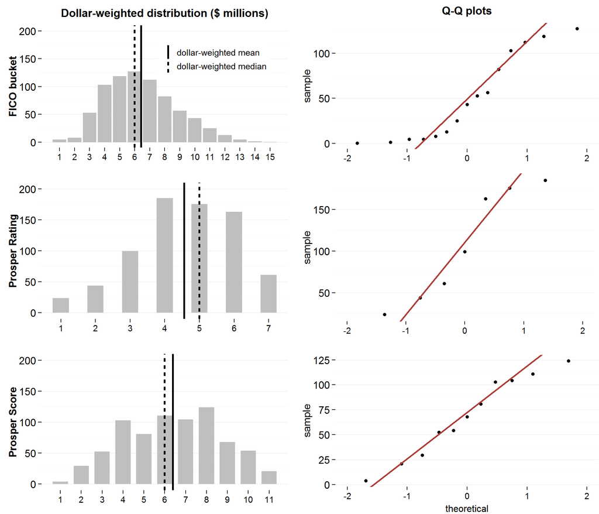

##### Note: FICO scores and Prosper ratings were renumbered in order from high to low risk score bucket. In the Q-Q plots on the right, data is arranged in ascending order on the y-axis. If the data is normally distributed, we would expect the yth point to be x standard deviations from the mean. Or to put it another way, the more the data falls on the straight line, the more normal its distribution. The three credit scoring systems are arranged from least to most normally distributed in the above figure.

In Figure 8 we can see that Prosper ratings have a much more left-skewed distribution, emphasizing the critical role unspecified adjustments play in changing the company’s credit opinion from base loss rates (calculated from FICO and Prosper scores). Also noteworthy, despite having closer mid-points, FICO scores and Prosper scores have a lower correlation than FICO scores and Prosper ratings in Figure 9. However, because Prosper scores exclude unspecified adjustments, I am more interested in differences between Prosper ratings and FICO scores.

#### Figure 9: Credit Score Correlation Matrix

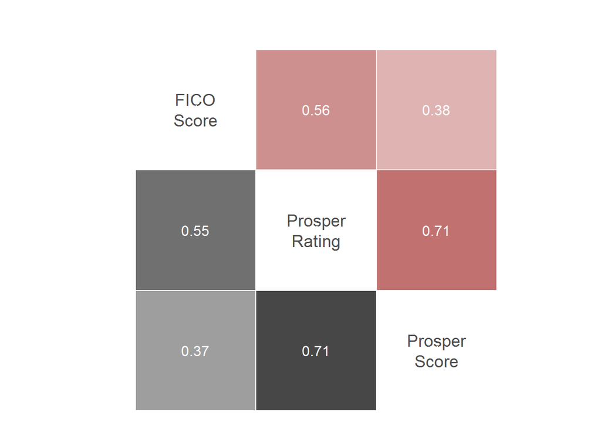

##### loan correlation in black/dollar correlation in red

It’s hard to draw solid conclusions from the above two figures without other data, such as the profiles of prospective borrowers that were rejected by Prosper, assuming it was more than the 5 cancelled loan listings in the data set.

## Default Prediction Accuracy

Throughout this report I have described models/algorithms as tools that are constantly being improved. When comparing the performance of credit models, we are really comparing the performance of different R&D teams. To operationalize this construct, I compare each model’s ability to predict dollar-weighted default using binary logistic regression in the following table.

#### Table 6: Binary Logistic Regression (Default Prediction Accuracy)

```
##
## Calls:
## fs.m: glm(formula = default ~ score, family = binomial(), data = fs.cb,
##     weights = dollars)
## pr.m: glm(formula = default ~ score, family = binomial(), data = pr.cb,
##     weights = dollars)
## ps.m: glm(formula = default ~ score, family = binomial(), data = ps.cb,
##     weights = dollars)
##
## ===============================================================
##                           fs.m          pr.m          ps.m
## ---------------------------------------------------------------
## (Intercept)             -0.260***      0.076***      0.054***
##                         (0.000)       (0.000)       (0.001)
## score                   -0.144***     -0.325***     -0.199***
##                         (0.000)       (0.000)       (0.000)
## ---------------------------------------------------------------
## Aldrich-Nelson R-sq.          0.025         0.050         0.034
## McFadden R-sq.                0.024         0.048         0.032
## Cox-Snell R-sq.               0.025         0.051         0.035
## Nagelkerke R-sq.              0.038         0.077         0.052
## phi                           1.000         1.000         1.000
## Likelihood-ratio        4259070.143   8668596.984   5819888.346
## p                             0.000         0.000         0.000
## Log-likelihood        -87776714.032 -85571950.612 -86996304.931
## Deviance              175553428.064 171143901.224 173992609.861
## AIC                   175553432.064 171143905.224 173992613.861
## BIC                   175553465.914 171143939.073 173992647.711
## N                     165568431     165568431     165568431
## ===============================================================
```

##### fs.m = FICO score, pr.m = Prosper ratings, ps.m = Prosper score.

#### Figure 10: Historic Default Probability with Regression Lines

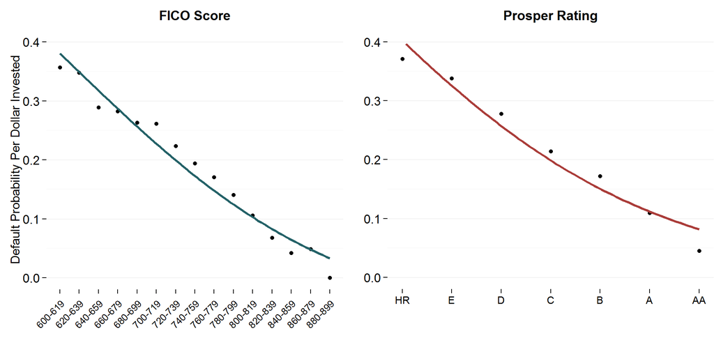

##### Note: when using logistic regression, an equivalent statistic to OLS R-squared does not exist. However, several pseudo R-squareds have been developed for logistic regression models. They are called pseudo R-squareds because they look like R-squared in the sense that they are on a similar scale, ranging from 0 to 1 (though some pseudo R-squareds never achieve 0 or 1) with higher values indicating better fit. But they cannot be interpreted as one would interpret an OLS R-squared and different pseudo R-squareds can arrive at very different values. While pseudo R-squareds cannot be interpreted independently or compared across datasets, they are valid and useful in evaluating multiple models predicting the same outcome on the same data set. In other words, a pseudo R-squared only has meaning when compared to another pseudo R-squared of the same type, on the same data, predicting the same outcome. In this situation, the higher pseudo R-squared indicates which model better predicts the outcome. To find out more about pseudo R-squareds, please visit this [link](http://www.ats.ucla.edu/stat/mult_pkg/faq/general/Psuedo_RSquareds.htm).

Looking at the bottom half of Table 6 we see that prosper rating (pr.m) has the best model fit, suggesting that variations in Prosper ratings served as better past predictors of dollar default than variations in the other two.

One likely explanation for FICO’s lower historic predictive power, is that FICO scores do not explicitly account for changes in the macroeconomic environment (e.g. spikes in base rates). They primarily serve as a barometer of relative impulsivity, time preference, risk attitude and trustworthiness among borrowers. Given the benign credit conditions reflected in the data set and the fact that we are still early in the 2013 cohort’s maturity cycle (more dollars outstanding than all previous vintages combined), the model rankings implied by the above table could quickly change in more turbulent market environments (e.g. the fed raises rates, China begins deleveraging). Another piece of the answer could lie in Prosper ratings adjustments for higher adverse selection risk: historically Prosper borrowers defaulted at a higher rate than the general population. Eitherway, from Figure 10 we can see that there’s not a big difference in default prediction accuracy between FICO score buckets and Prosper ratings historically.

At this point, the biggest questions I have about Prosper ratings revolve around how distributions change over time and how Prosper incorporates FICO scores without knowing how that score is calculated. For example, how do Prosper scores change when a new FICO generation is introduced? How would a rise in interest rates affect relative distributions?

Without knowing more about the inner workings of Prosper’s risk model, the above table has limited predictive power. It serves more as a snapshot of a recent step along an increasingly hidden evolutionary path. For instance, earlier this year the company switched from releasing daily loan data updates to [delayed updates 45 days after the close of the quarter](http://blog.prosper.com/2015/01/26/prosper-updates-its-data-policies-and-reiterates-commitment-to-investors-and-data-quality/). Here’s an excerpt from the press release describing the company’s rational (emphasis mine):

> *We are making these changes in order to protect our intellectual property and proprietary data*, not to inhibit our clients who are using the data for their credit models and to make investment decisions. We understand that our investors need our data to analyze investment performance, but we also need *to ensure that people can’t reverse engineer our underwriting model. One of Prosper’s main competitive advantages is our data asset…*

Since then, the company has added new data assets and sales channels through two acquisitions:

1. **American Healthcare**: a network that gives doctors and other healthcare providers the ability to offer loans to patients for elective medical procedures at their offices.
2. **Billguard**: an app that helps consumers stay an budget, track their spending, and monitor their credit for fraudulent purchases. After the acquisition, Prosper announced that it would give the app for free to all outstanding borrowers and investors.

How future generations of Prosper’s credit risk models backed by these new assets will perform against those of other lenders is anyone’s guess. That depends not only on the technology/data each R&D team has access to, but also how each team interprets the data. This [article on the flawed credit risk models that sparked the financial crisis](http://www.wired.com/2009/02/wp-quant/) highlights the importance of sanity checking assumptions against sound [domain knowledge](http://www.economicprinciples.org/wp-content/uploads/ray_dalio__how_the_economic_machine_works__leveragings_and_deleveragings.pdf#page=2).

## Prosper Ratings Expected Returns and Borrowing Rates Through Time

To summarise the story so far, let’s take a look at the evolution of lender expected returns and borrower loan rates through time. Thoughout this section I use 36 month loan data (largest maturity bucket in Figure 6) to avoid adding noise related to changes in the term structure of risk (changes in relative levels of rates and risk spreads for different maturities in Figure 4).

The chaos to order pattern (higher returns for higher investment risk) seen in the expected return by loan risk in Figure 11 reflects step-wise adjustments to Prosper’s lending process and a recovery of confidence in broader credit markets.

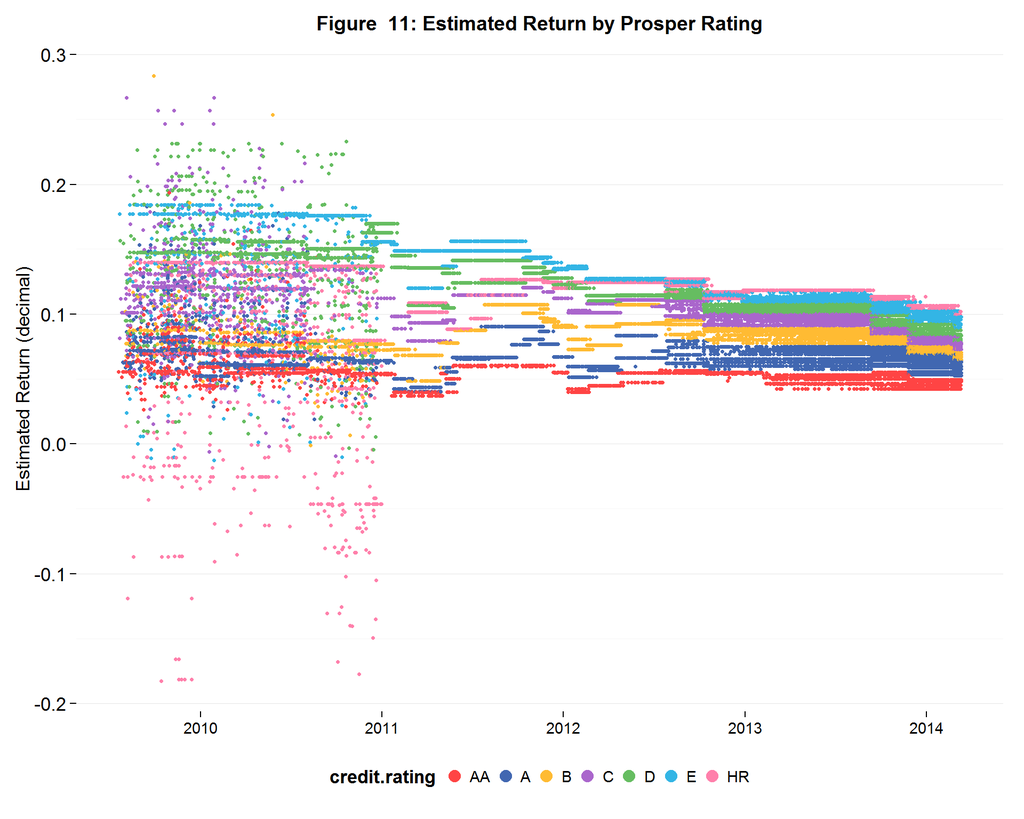

After smoothing Figure 11 using 10-day dollar-weighted moving averages, we see a dramatic rise in the expected return for high-risk loans through time, reflecting the idea that investors need to be lured by higher expected returns to assume higher uncertainty (i.e. risk-adjusted returns).

If we had the data, I would be interested in seeing how historic Prosper Ratings would change using the company’s most recent risk scoring methodology.

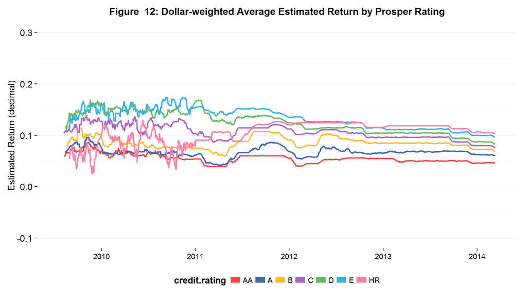

Looking at the same loans through borrower eyes in Figure 13, we see a similar reduction in rate volatility through time. *Note: most of the difference between expected investor return (Figure 11) and borrowing rate (Figure 13) is the expected loss rate (probability of borrower default multiplied by the loss given default).*

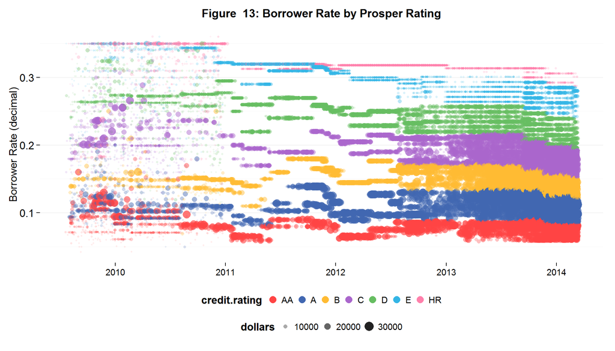

By adding another aesthetic layer with transaction size (dollars) in Figure 13, we can see changes in market liquidity and investor behavior that may signal possible regime shifts in the data set. For example, from the start of 2011 to the middle of 2012, there were fewer small loan transactions, indicating a lull in retail investing activity. Instead, this period was dominated by large clumps of concentrated loan buying by [hedge funds](http://www.economist.com/news/special-report/21650289-will-financial-democracy-work-downturn-people-people). It’s likely that the jump in loan growth between 2010 and 2011 coincides with significant changes to Prosper’s data strategy (models, algorithms, client data access), explaining higher default rates for those periods.

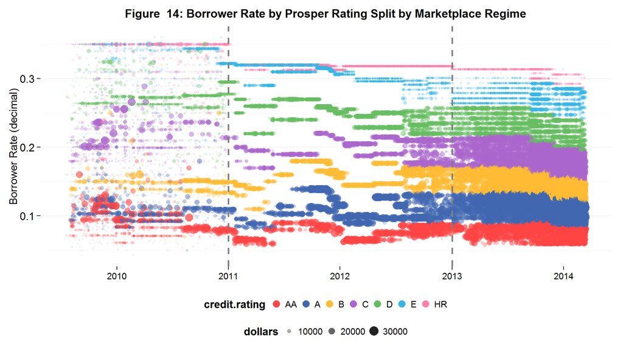

To lay some ground work for the next section, in Figure 14 I marked the shift in marketplace environment described above as well as a second shift that occurred at the beginning of 2013. To shed some light on this more recent shift, in Prosper’s [2013 annual report](https://www.sec.gov/Archives/edgar/data/1416265/000114036114014832/form10k.htm) (p. 13) the company says that changes made to its risk management process between 2012Q4-2013Q1 were expected to result in meaningfully lower default rates compared to those on loans issued between 2011 and the first half of 2012. 2013Q1 also coincides with the dip in first quarter loan growth in Figure 3 and the start of the low volatility period in Figure 12, suggesting that it was a key transition period for Prosper’s lending platform.

Return to table of contents

# FINAL PLOTS AND SUMMARY

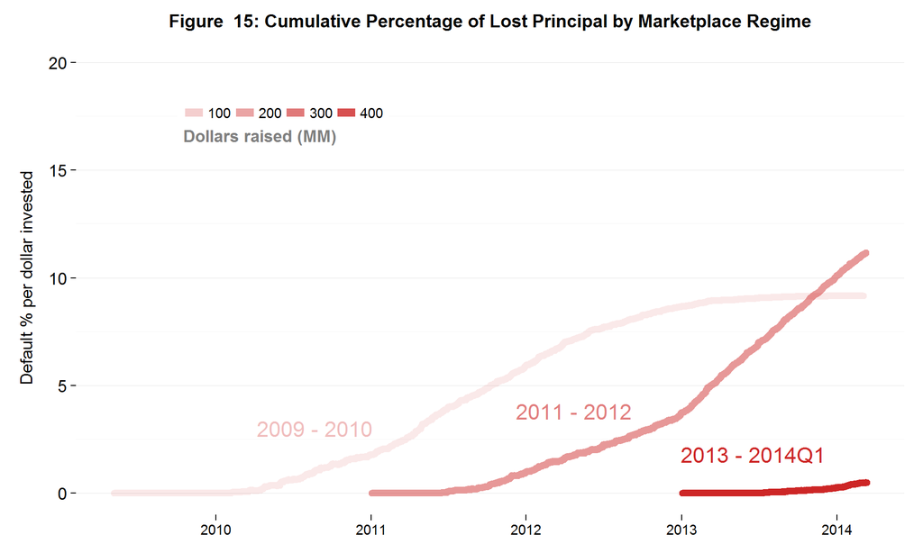

```
## Source: local data frame [3 x 5]
## Groups: regime [3]
##
##        regime dollars.raised dollars.outstanding pct.matured pct.charged.off
##        (fctr)          (dbl)               (dbl)       (dbl)           (dbl)
## 1   2009-2010       35854882              310300        99.1             9.2
## 2   2011-2012      228313129           121604898        46.7            11.2
## 3 2013-2014Q1      497388382           473379617         4.8             0.5
```

In Figure 15 I group loan data by regimes identified in Figure 14 instead of calendar year (Figure 5). Remember that one of the major challenges faced by the P2P industry is finding enough creditworthy borrowers to satisfy investor appetites and wall street growth expectations. From Figure 15 it looks like Prosper had to relax lending standards in 2011 and 2012 to create enough loan supply to accomplish this, explaining the kink and sharp rise in charge-offs midway through the 2011-2012 default curve.

The company confirms higher risk 2011 loan issuance only in their [2012 10-K (p. 13)](https://www.prosper.com/Downloads/Legal/prosper10k12312012.pdf), when they can’t hide the fact that 2011 vintage cumulative default rates have overtaken 2009 and 2010 default rates in Figure 5:

> Some of the higher risk observed in the 2011 vintages is a result of increased percentages of higher risk loans being originated during this time period.

For 2012 issuance, again, the company only discloses increased risk taking after the fact. Instead of mentioning higher risk 2012 loan issuance in their 2012-10K, the company waits until their [2013-10K (p. 16)](https://www.prosper.com/Downloads/Legal/prosper10k12312013.pdf), when higher than expected 2012 default rates make it impossible to hide (Figure 5).

> In many rating grades, risk is trending above estimates for the 2011 and 2012 vintages. . . .To date, all of the 2013Q1 and 2013Q2 vintages have cumulative losses below their respective estimated lines. The PMI Group considers this change in performance to be a direct result of changes made by PMI to its risk management practices at the end of 2012 and the beginning of 2013

These after the fact disclosures damage the company’s credibility and cast doubt on my earlier opinion of low 2013 vintage cumulative default rates in Figure 5. More specifically, the kink in Figure 15 makes me wonder if I should expect a similar acceleration in defaults for 2013 loan inventory issued later in the year. Let’s look at the distribution of higher risk FICO score buckets across Prosper Ratings from 2013 onward to see if there’s cause for concern.

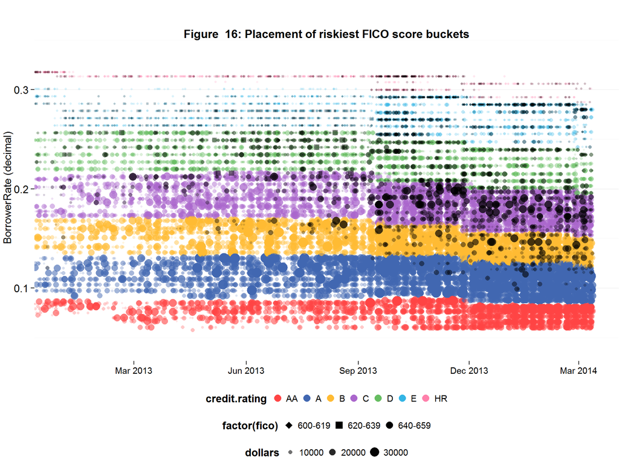

Figure 16 confirms my suspicions. We see an unmistakable spike in riskier FICO score loan issuance to accommodate the large jump in late year transaction volumes in Figure 3. This back-end risk loading is likely motivated by Prosper’s desire to make up for the slowdown in 2013Q1 to manufacture the attractive annual growth curves in Figure 3.

Another motivation for rapid loan growth is for the temporary cosmetic effect on cumulative default rates for Prosper 2.0 loans. For example, a 10% default rate will become 5% if Prosper’s loan book doubles and defaults have yet to materialize on newer loan vintages because riskier issuance was calendar backloaded.

#### Figure 17: Credit Rating Distributions 2013

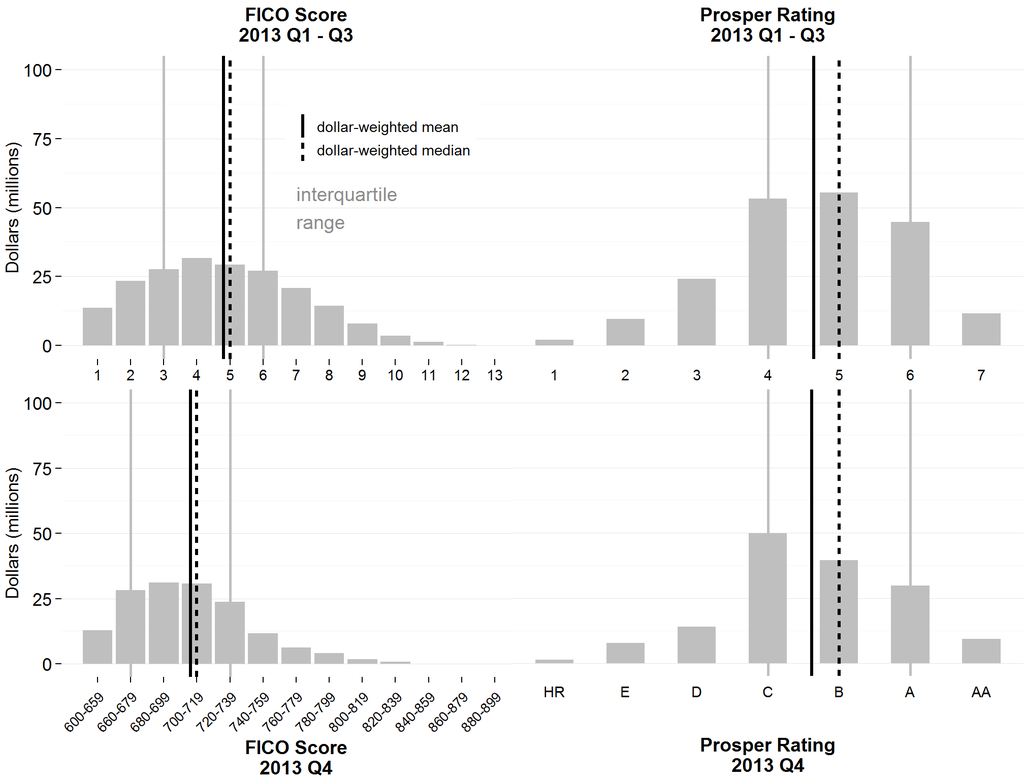

##### Note: Prosper raised its minium FICO score from 600 to 640 in 2013Q4. Prior to that period, certain repeat borrowers in good standing with FICO scores below 640 could borrow. In the FICO distribution, I combined FICO score buckets 600-619, 620-639, and 640-659 to simplify presentation.

The company doesn’t mention any Q4 risk management changes in their 2013 annual report, but makes it a point to highlight rising quarterly loan growth numbers with the only chart in the management discussion section of their annual report.

#### Figure 18: FICO vs Prosper Rating Distribution Through Time

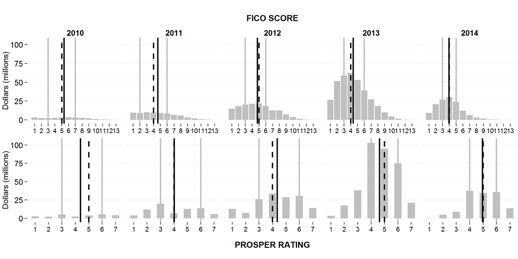

From a higher vantage point in Figure 18, we can see that the divergence between FICO and Prosper ratings distributions in Figure 17 is actually part of a longer term trend, with 2013 and 2014 marking the first loan vintages where interquartile ranges for FICO score and Prosper ratings don’t overlap.

Prosper proponents would argue that this widening variance reflects new algorithms finding their footing. But another possibility is that black box algorithms/models are being used to hide riskier issuance necessary to meet growth targets. The similar default prediction accuracy of FICO and Prosper ratings in Figure 10 makes the growing ratings divergence look like the company is making an undisclosed macroeconomic bet that interest rates and risk spreads (probability of default) will remain low for the foreseeable future.

## Reflection

Because Prosper directs investor capital into credit opportunities that it finds and prices, the firm should be treated as an asset manager. And as such, Prosper has a fiduciary duty to its investors to explain what it’s doing with their money and why. This does not mean that the company has to share secrets of proprietary technology, but in a post-Madoff era, the firm should educate clients about material changes to its investment strategy on a prospective basis. It really looks bad when management repeatedly slips in after-the-fact disclosures about increased risk taking that could have affected ex-ante investment risk/return expectations of past investors (see: [Is the black-box hedge fund model doomed?](http://www.bloomberg.com/professional/blog/is-the-black-box-hedge-fund-model-doomed/)).

It’s hard to say how much of a cost advantage P2P lenders have (if any) to undercut borrowing rates offered by traditional lenders. Even if we dismiss claims of superior screening and underwriting technology, P2P lenders likely have lower regulatory costs than banks because there’s a lower likelihood they will need to be bailed out with tax payer money<sup>1</sup>. While banks, on the other hand, likely have lower marketing and inventory acquisition costs arising from more diverse sales channels and powerful brands. Until I get more data to analyze (particularly Lending Club data), these areas will remain unexplored avenues for future research.

The biggest challenge I faced when writing this report came from trying to connect each visualization to an overarching narrative. I found as I moved towards more complex multivariate visualizations, I had to conduct more granular domain research to square new relationships/insights with earlier, more naive, interpretations of the data. This recursive reconciliation process, though mentally taxing, helped be better streamline my research efforts. For instance, instead of having to read through 500 pages of annual reports, I only had to sift through 4-5 pages worth of keyword queries related to higher defaults on 2011 and 2012 loan vintages (Figure 15), to find all I needed to know about company transparency.

When I compare the visualizations created in this report with what I could have otherwise produced in Excel, it’s a non-starter. A simple column calculation in Excel with Prosper loan data locked up the program for a good five minutes. Moreover, many of the above visualizations can’t be easily recreated in Excel, in particular, anything in the final plots section. To deny the superiority of R over Excel for exploratory data analysis, is to admit ignorance.

##### <sup>1</sup> Banks fund most of their lending using low interest customer deposits-that are supposed to be risk free (guaranteed by the government)—capturing the difference between lending and depositor rates as profit . If a bank incurs enough losses to put deposits at risk, the government has to step in to rescue the bank or risk a system-wide liquidity crisis (see fractional reserve banking). In stark contrast, investors who lend through peer-to-peer platforms accept a higher likelihood of loss in exchange for higher expected returns (risk-adjusted returns), relieving P2P lenders from having to pay the insurance cost of government guarantees (deposit insurance and risk-weighted capital buffers).

Return to table of contents

# REFERENCES

1. https://www.bea.gov/
2. http://www.housingwire.com/articles/29707-the-states-and-cities-with-the-most-underwater-homes
3. http://www.federalreserve.gov/releases/g19/current/#table3
4. http://www.newyorkfed.org/householdcredit/2013-Q4/HHDC_2013Q4.pdf
5. http://www.economicprinciples.org/
6. http://www.federalreserve.gov/releases/g19/current/#table3
7. http://www.bloomberg.com/professional/blog/is-the-black-box-hedge-fund-model-doomed/
8. http://www.economist.com/news/special-report/21650289-will-financial-democracy-work-downturn-people-people
9. https://www.prosper.com/prospectus/
10. http://www.wired.com/2009/02/wp-quant/
11. http://blog.prosper.com/2015/01/26/prosper-updates-its-data-policies-and-reiterates-commitment-to-investors-and-data-quality/
12. http://www.ats.ucla.edu/stat/mult_pkg/faq/general/Psuedo_RSquareds.htm
13. http://blogs.reuters.com/felix-salmon/2010/01/19/the-problem-with-peer-to-peer-lending/
14. https://cs.stanford.edu/people/jure/pubs/prosper-www11.pdf
15. https://github.com/adletaw/captioner
16. http://stackoverflow.com/questions/4835332/how-can-i-combine-multiple-ggplot2-elements-into-the-return-of-a-function
17. http://stackoverflow.com/questions/11020437/consistent-width-for-geom-bar-in-the-event-of-missing-data
18. https://github.com/hadley/ggplot2/wiki/Axis-Attributes
19. http://haleyai.com/wordpress/2008/05/08/probabilities-are-better-than-scores/
20. http://stackoverflow.com/questions/5823503/pattern-matching-using-a-wildcard
21. http://kbroman.org/knitr_knutshell/pages/Rmarkdown.html
22. https://dl.dropboxusercontent.com/u/5896466/wrangling-webinar.pdf
23. https://discussions.udacity.com/t/project-details/30778/3
24. http://daisukeichikawa.blogspot.com/2014/03/tips-for-rmaps-and-rcharts.html
25. http://zevross.com/blog/2014/08/04/beautiful-plotting-in-r-a-ggplot2-cheatsheet-3/
26. http://www.economist.com/news/leaders/21650546-wave-startups-changing-financefor-better-fintech-revolution
27. http://www.wsj.com/articles/online-lenders-rely-on-old-school-marketing-1443736411